# Capital Punishment in the U.S.

STT2860 Project 02 Fall 2022

Kate Metzger, Hannah Joyner, and Jordan Klein

Tuesday, November 15, 2022 @ 04:19 PM

### Packages Used

```r
library(tidyverse)
library(ggplot2)
```

### Read Data Files

```r
cappunish <- read_rds("cappunish.rds")
deathrowsize <- read_rds("deathrowsize.rds")
deathsentencesNC <- read_rds("deathsentencesNC.rds")
```

### Plot #1: How Many States Have Capital Punishment?

- Create a barplot for the variable `dp2`.
- Use `color =` and `fill =` to format the bars.
- Use `labs()` to add a title and better axis labels.
- Apply a built-in theme from **ggplot2** or **ggthemes**.
- You may optionally add a subtitle or caption to the plot.
- This plot should *not* have a visible legend anywhere on it.

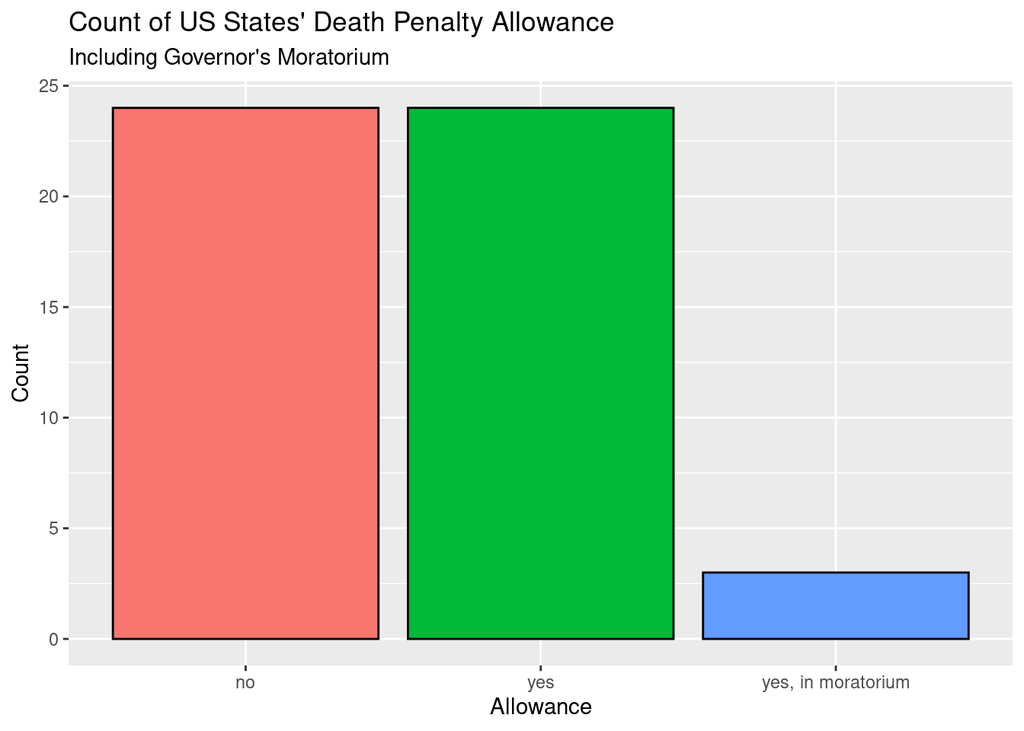

```r
ggplot(cappunish, aes(x = dp2, fill = dp2)) +
  geom_bar(color = "black") +
  labs(title = "Count of US States' Death Penalty Allowance",
       subtitle = "Including Governor's Moratorium") +
  xlab("Allowance") +
  ylab("Count") +
  theme(legend.position = "none")
```

### Plot #2: Capital Punishment By Region of the U.S.

- Create a barplot for the variable `region`.
- Use `fill =` to shade each bar according to `dp2`.
- Change the `position =` to set each bar equal to 100%.
- Use `width =` to make the bars narrower than the default.
- Use `labs()` to add a title, axis labels, and a better legend label.
- Use `scale_fill_manual()` to choose a different color scheme for the plot.
- Use `theme()` to move the legend to the bottom of the plot instead of the right
- You may optionally add a subtitle, caption, or ggplot2 built-in theme to the plot.

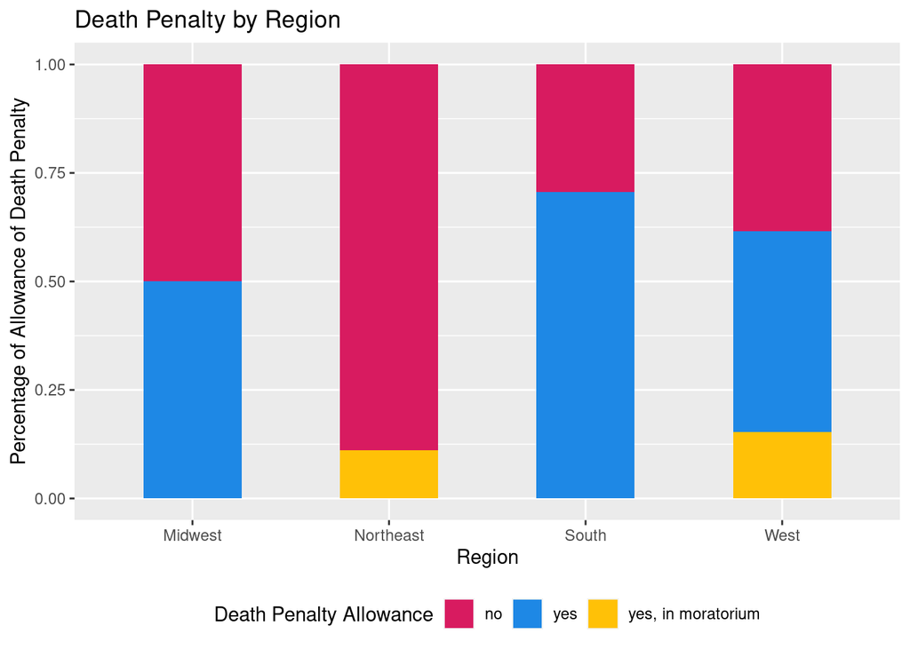

```r
ggplot(cappunish, aes(x = region, fill = dp2)) +
  geom_bar(position = "fill", width = 0.5) +
  labs(title = "Death Penalty by Region",
       x = "Region",
       y = "Percentage of Allowance of Death Penalty",
       fill = "Death Penalty Allowance") +
  scale_fill_manual(values = c("#D81B60", "#1E88E5", "#FFC107")) +
  theme(legend.position = "bottom")
```

### Plot #3: Number of Prisoners on Death Row

- Create a barplot for the total number of prisoners (y) in each year (x).
- Fill the bars using the variable `decade` and outline them all in black.
- Set the width of all the bars so there is no visible gap in between them.
- Scale the x-axis to include a tick mark at each decade (1970, 1980, etc).
- Scale the y axis so that it is numbered 0, 500, 1000, 1500, 2000, etc.
- Use `labs()` to add or change the title, axis labels, and legend label.
- Use `theme()` to do the following:
  - center your title
  - set the plot background to white or blank
  - set all axis tick marks to transparent or blank
  - set the major x-axis gridlines to transparent or blank
  - set the major y-axis gridlines to light gray
- You may optionally change the bar color scheme used in your plot

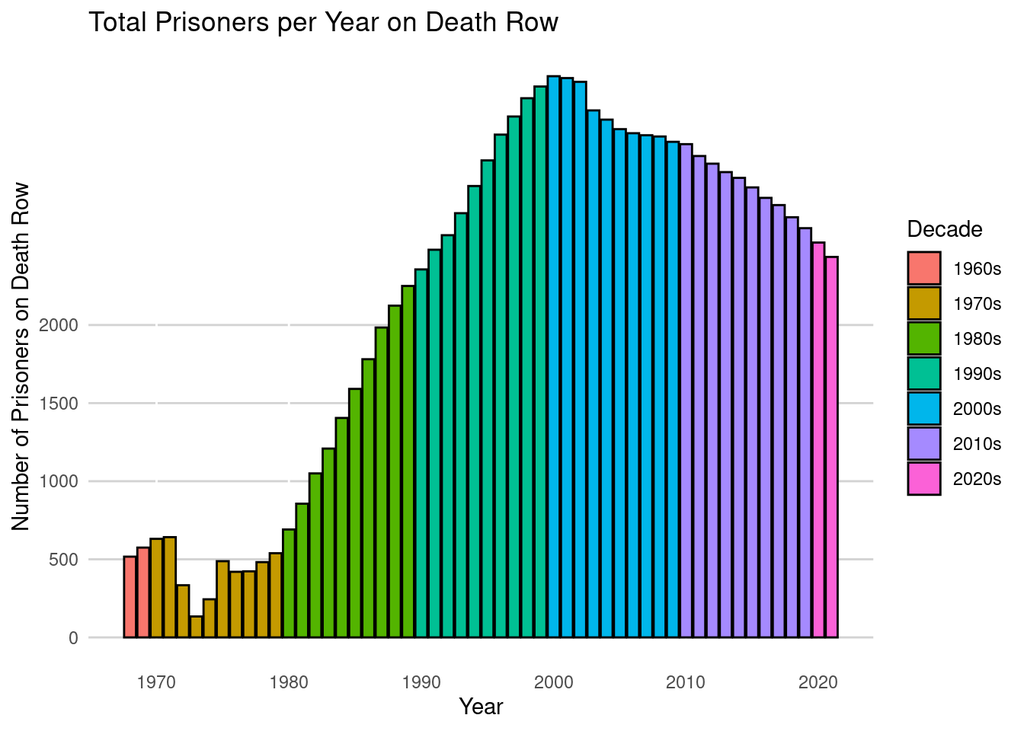

```r
ggplot(deathrowsize, aes(x = year, y = total, fill = decade)) +
  geom_col(color = "black") +
  labs(title = "Total Prisoners per Year on Death Row",
       x = "Year",
       y = "Number of Prisoners on Death Row",
       fill = "Decade") +
  theme(panel.background = element_blank(),
        axis.ticks = element_blank(),
        panel.grid.major.y = element_line(color = "lightgray")) +
  scale_x_continuous(breaks = seq(1960, 2020, 10)) +
  scale_y_continuous(breaks = seq(0, 2000, 500))
```

### Plot #4: Number of Executions Since 1976

- Create a violin plot for the variable `post1976` (use `y = 0`)
- Add a boxplot and set the width so it fits inside the violin plot
- Fill each plot with a color of your choice (be colorblind-aware)
- Scale the x-axis of the plot so that it counts in increments of 25
- Get rid of all y-axis markings/gridlines using `scale_y_continuous()`
- Add a title, x-axis label, and a caption to identify the large outlier
- Add the built-in theme `theme_linedraw()` or `theme_minimal` to the plot

Hint: You can use the `NULL` vector in functions like `scale_y_continuous()`

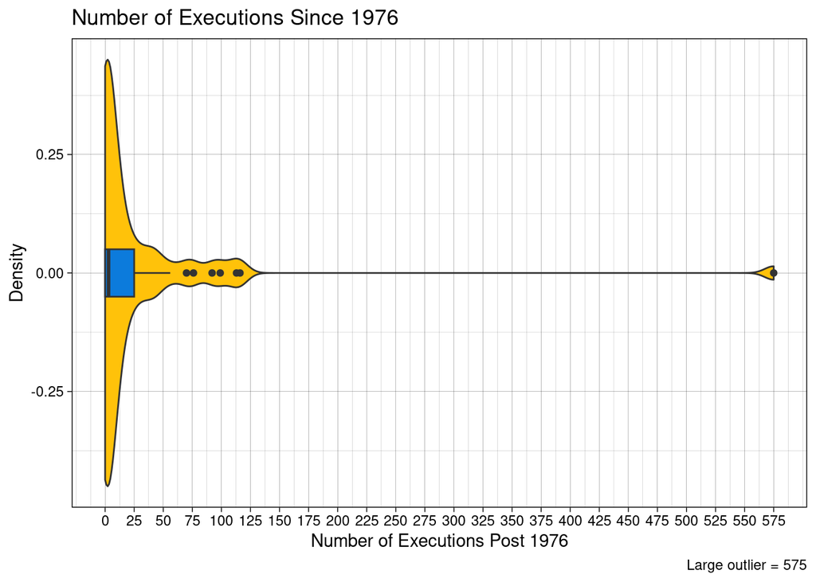

```r
ggplot(cappunish, aes(x = post1976, y = 0)) +
  geom_violin(fill = "#FFC20A") +
  geom_boxplot(width = 0.1, fill = "#0C7BDC") +
  scale_x_continuous(breaks = seq(0,575, 25)) +
  theme(panel.grid.major.y = element_line(color = "transparent"),
        panel.grid.minor.y =  element_line(color="transparent")) +
  labs(title = "Number of Executions Since 1976",
       x = "Number of Executions Post 1976",
       y = "Density",
       caption = "Large outlier = 575") +
  theme_linedraw()
```

### Plot #5: Death Sentences in NC Since 1976

Create a time series plot of death sentences in North Carolina. Use three geometries on this plot: `geom_area()`, `geom_line()` and `geom_point()`. Use `geom_vline()` to add a vertical line for 2001. The significance of this year is that the General Assembly modified the death penalty statute in several ways, including giving prosecutors the discretion to *not* seek the death penalty in cases where it previously would have been mandatory. Format and label your plot in such a way that the information it conveys would be clear to the reader (i.e., the plot is reasonably stand-alone).

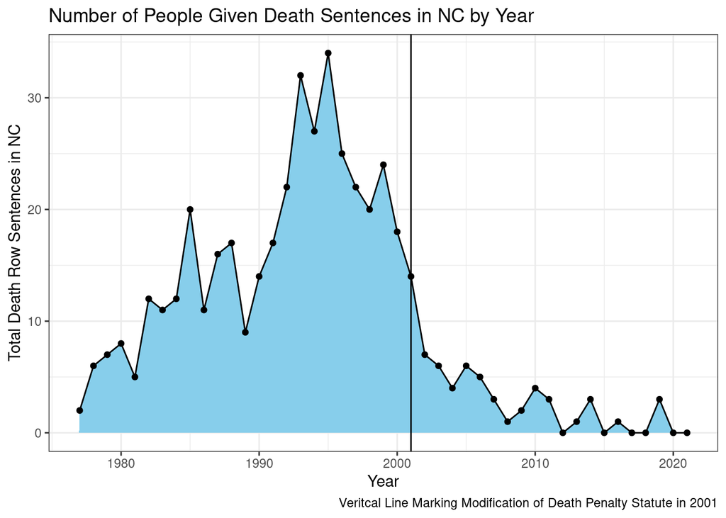

```r
ggplot(deathsentencesNC, aes(x = year, y = sentences)) +
  geom_area(fill = "skyblue") +
  geom_line() +
  geom_point() +
  geom_vline(xintercept = 2001) +
  labs(x = "Year",
       y = "Total Death Row Sentences in NC",
       title = "Number of People Given Death Sentences in NC by Year",
       caption = "Veritcal Line Marking Modification of Death Penalty Statute in 2001") +
  theme_bw()
```

### Information Conveyed by Your Plots

List two pieces of information you can learn or comparisons you can make from each plot above.

#### Plot #1

- Item 1: The count of US States’ Death Penalty Allowance is about half and half between allowing and not allowing.
- Item 2: Only three states accepted the Death Penalty in Moratorium.

#### Plot #2

- Item 1: The South has the highest percentage of yes to the death penalty.
- Item 2: The Northeast has 0% in support of the death penalty with the exception of in moratorium. Additionally, it is interesting to note that the Midwest is exactly 50/50.

#### Plot #3

- Item 1: Peak of Death Row Sentences in the early 2000’s, specifically in 2000 at 3,593 sentences.
- Item 2: Drastic increase in numbers of prisoners on Death Row in the 1980’s by about 1,500.

#### Plot #4

- Item 1: Bulk of the data is closer to zero, meaning that most states had a low number of executions since 1976.
- Item 2: There is a large outlier state, Texas, at 575 executions since 1976.

#### Plot #5

- Item 1: Death penalty sentences drastically went down after the year 2001. This could be due to the General Assembly modified the death penalty statute in several ways, including giving prosecutors the discretion to not seek the death penalty in cases where it previously would have been mandatory.
- Item 2: There is a peak at 34 total death row sentences in 1995 preceding the death penalty statute modification.